# Taller R: Sesion 2

Maria Jose Zambrano

2023-10-11

En este sesión veremos algunas cosas utiles a la hora de trabajar con datos, exploración, limpieza y manjeo de dataframes.

# Ayuda

Pero antes de partir algo que puede ser util, a veces uno quiere saber como funciona una funcion, que argumentos tiene etc. Para esto y no entrar en panico podemos pedirle ayuda a R:

```r
help("read.csv")
```

```
## starting httpd help server ... done
```

Le pasamos la funcion que queremos a help y nos va a mostrar la documentaion.

# Analisis exploratorio (EDA)

Ahora si a los datitos.

Realizar exploraciones iniciales con los datos, para ver que datos tenemos, como son, si hay nulos, si es necesario limpiarlos etc. Para ver todo esto vamos a usar un dataset con datos de airbnb de nueva york.

```r
df <- read.csv("./Datasets/AB_NYC_2019.csv")
```

Ver como es el dataset con head:

```r
head(df)
```

```
##     id                                             name host_id   host_name
## 1 2539               Clean & quiet apt home by the park    2787        John
## 2 2595                            Skylit Midtown Castle    2845    Jennifer
## 3 3647              THE VILLAGE OF HARLEM....NEW YORK !    4632   Elisabeth
## 4 3831                  Cozy Entire Floor of Brownstone    4869 LisaRoxanne
## 5 5022 Entire Apt: Spacious Studio/Loft by central park    7192       Laura
## 6 5099        Large Cozy 1 BR Apartment In Midtown East    7322       Chris
##   neighbourhood_group neighbourhood latitude longitude       room_type price
## 1            Brooklyn    Kensington 40.64749 -73.97237    Private room   149
## 2           Manhattan       Midtown 40.75362 -73.98377 Entire home/apt   225
## 3           Manhattan        Harlem 40.80902 -73.94190    Private room   150
## 4            Brooklyn  Clinton Hill 40.68514 -73.95976 Entire home/apt    89
## 5           Manhattan   East Harlem 40.79851 -73.94399 Entire home/apt    80
## 6           Manhattan   Murray Hill 40.74767 -73.97500 Entire home/apt   200
##   minimum_nights number_of_reviews last_review reviews_per_month
## 1              1                 9  2018-10-19              0.21
## 2              1                45  2019-05-21              0.38
## 3              3                 0                            NA
## 4              1               270  2019-07-05              4.64
## 5             10                 9  2018-11-19              0.10
## 6              3                74  2019-06-22              0.59
##   calculated_host_listings_count availability_365
## 1                              6              365
## 2                              2              355
## 3                              1              365
## 4                              1              194
## 5                              1                0
## 6                              1              129
```

Explorar cuantas dimensiones tiene:

```r
dim(df)
```

```
## [1] 48895    16
```

Con str podemos ver las columnas del dataframe con su tipo:

```r
str(df)
```

```
## 'data.frame':    48895 obs. of  16 variables:
##  $ id                            : int  2539 2595 3647 3831 5022 5099 5121 5178 5203 5238 ...
##  $ name                          : chr  "Clean & quiet apt home by the park" "Skylit Midtown Castle" "THE VILLAGE OF HARLEM....NEW YORK !" "Cozy Entire Floor of Brownstone" ...
##  $ host_id                       : int  2787 2845 4632 4869 7192 7322 7356 8967 7490 7549 ...
##  $ host_name                     : chr  "John" "Jennifer" "Elisabeth" "LisaRoxanne" ...
##  $ neighbourhood_group           : chr  "Brooklyn" "Manhattan" "Manhattan" "Brooklyn" ...
##  $ neighbourhood                 : chr  "Kensington" "Midtown" "Harlem" "Clinton Hill" ...
##  $ latitude                      : num  40.6 40.8 40.8 40.7 40.8 ...
##  $ longitude                     : num  -74 -74 -73.9 -74 -73.9 ...
##  $ room_type                     : chr  "Private room" "Entire home/apt" "Private room" "Entire home/apt" ...
##  $ price                         : int  149 225 150 89 80 200 60 79 79 150 ...
##  $ minimum_nights                : int  1 1 3 1 10 3 45 2 2 1 ...
##  $ number_of_reviews             : int  9 45 0 270 9 74 49 430 118 160 ...
##  $ last_review                   : chr  "2018-10-19" "2019-05-21" "" "2019-07-05" ...
##  $ reviews_per_month             : num  0.21 0.38 NA 4.64 0.1 0.59 0.4 3.47 0.99 1.33 ...
##  $ calculated_host_listings_count: int  6 2 1 1 1 1 1 1 1 4 ...
##  $ availability_365              : int  365 355 365 194 0 129 0 220 0 188 ...
```

Y ver un resumen estadístico con summary:

```r
summary(df)
```

```
##        id               name              host_id           host_name
##  Min.   :    2539   Length:48895       Min.   :     2438   Length:48895
##  1st Qu.: 9471945   Class :character   1st Qu.:  7822033   Class :character
##  Median :19677284   Mode  :character   Median : 30793816   Mode  :character
##  Mean   :19017143                      Mean   : 67620011
##  3rd Qu.:29152178                      3rd Qu.:107434423
##  Max.   :36487245                      Max.   :274321313
##
##  neighbourhood_group neighbourhood         latitude       longitude
##  Length:48895        Length:48895       Min.   :40.50   Min.   :-74.24
##  Class :character    Class :character   1st Qu.:40.69   1st Qu.:-73.98
##  Mode  :character    Mode  :character   Median :40.72   Median :-73.96
##                                         Mean   :40.73   Mean   :-73.95
##                                         3rd Qu.:40.76   3rd Qu.:-73.94
##                                         Max.   :40.91   Max.   :-73.71
##
##   room_type             price         minimum_nights    number_of_reviews
##  Length:48895       Min.   :    0.0   Min.   :   1.00   Min.   :  0.00
##  Class :character   1st Qu.:   69.0   1st Qu.:   1.00   1st Qu.:  1.00
##  Mode  :character   Median :  106.0   Median :   3.00   Median :  5.00
##                     Mean   :  152.7   Mean   :   7.03   Mean   : 23.27
##                     3rd Qu.:  175.0   3rd Qu.:   5.00   3rd Qu.: 24.00
##                     Max.   :10000.0   Max.   :1250.00   Max.   :629.00
##
##  last_review        reviews_per_month calculated_host_listings_count
##  Length:48895       Min.   : 0.010    Min.   :  1.000
##  Class :character   1st Qu.: 0.190    1st Qu.:  1.000
##  Mode  :character   Median : 0.720    Median :  1.000
##                     Mean   : 1.373    Mean   :  7.144
##                     3rd Qu.: 2.020    3rd Qu.:  2.000
##                     Max.   :58.500    Max.   :327.000
##                     NA's   :10052
##  availability_365
##  Min.   :  0.0
##  1st Qu.:  0.0
##  Median : 45.0
##  Mean   :112.8
##  3rd Qu.:227.0
##  Max.   :365.0
##
```

Table nos permite realizar un conteo de cada clase cuando le pasamos una columna:

```r
table(df$neighbourhood_group)
```

```
##
##         Bronx      Brooklyn     Manhattan        Queens Staten Island
##          1091         20104         21661          5666           373
```

También le podemos pasar más de una para que nos haga un conteo de las combinaciones:

```r
table(df$neighbourhood_group,df$neighbourhood)
```

```
##
##                 Allerton Arden Heights Arrochar Arverne Astoria Bath Beach
##   Bronx               42             0        0       0       0          0
##   Brooklyn             0             0        0       0       0         17
##   Manhattan            0             0        0       0       0          0
##   Queens               0             0        0      77     900          0
##   Staten Island        0             4       21       0       0          0
##
##                 Battery Park City Bay Ridge Bay Terrace
##   Bronx                         0         0           0
##   Brooklyn                      0       141           0
##   Manhattan                    70         0           0
##   Queens                        0         0           6
##   Staten Island                 0         0           0
##
##                 Bay Terrace, Staten Island Baychester Bayside Bayswater
##   Bronx                                  0          7       0         0
##   Brooklyn                               0          0       0         0
##   Manhattan                              0          0       0         0
##   Queens                                 0          0      39        17
##   Staten Island                          2          0       0         0
##
##                 Bedford-Stuyvesant Belle Harbor Bellerose Belmont Bensonhurst
##   Bronx                          0            0         0      24           0
##   Brooklyn                    3714            0         0       0          75
##   Manhattan                      0            0         0       0           0
##   Queens                         0            8        14       0           0
##   Staten Island                  0            0         0       0           0
##
##                 Bergen Beach Boerum Hill Borough Park Breezy Point Briarwood
##   Bronx                    0           0            0            0         0
##   Brooklyn                10         177          136            0         0
##   Manhattan                0           0            0            0         0
##   Queens                   0           0            0            3        56
##   Staten Island            0           0            0            0         0
##
##                 Brighton Beach Bronxdale Brooklyn Heights Brownsville
##   Bronx                      0        19                0           0
##   Brooklyn                  75         0              154          61
##   Manhattan                  0         0                0           0
```

[output cut: 274 more lines]

```
##   Staten Island          0            0                  0           2
##
##                 Whitestone Williamsbridge Williamsburg Willowbrook
##   Bronx                  0             40            0           0
##   Brooklyn               0              0         3920           0
##   Manhattan              0              0            0           0
##   Queens                11              0            0           0
##   Staten Island          0              0            0           1
##
##                 Windsor Terrace Woodhaven Woodlawn Woodrow Woodside
##   Bronx                       0         0       11       0        0
##   Brooklyn                  157         0        0       0        0
##   Manhattan                   0         0        0       0        0
##   Queens                      0        88        0       0      235
##   Staten Island               0         0        0       1        0
```

Algo importante siempre, ver si nuestro dataset tiene datos nulos:

```r
any(is.na(df))
```

```
## [1] TRUE
```

Y los podemos contar por columna para tener todo bien claro:

```r
null_count <- colSums(is.na(df))
print(null_count)
```

```
##                             id                           name
##                              0                              0
##                        host_id                      host_name
##                              0                              0
##            neighbourhood_group                  neighbourhood
##                              0                              0
##                       latitude                      longitude
##                              0                              0
##                      room_type                          price
##                              0                              0
##                 minimum_nights              number_of_reviews
##                              0                              0
##                    last_review              reviews_per_month
##                              0                          10052
## calculated_host_listings_count               availability_365
##                              0                              0
```

También podemos ver las correlaciones entre las distintas variables numericas con cor. Esto es muy util cuando queremos aplicar algoritmos de clasificacion o regresion, tambien para ver si podemos eliminar alguna columna que no aporte mucha informacion.

```r
numeric_dataset <- df[sapply(df, is.numeric)]
cor(numeric_dataset)
```

```
##                                          id     host_id     latitude
## id                              1.000000000  0.58829015 -0.003125295
## host_id                         0.588290148  1.00000000  0.020224187
## latitude                       -0.003125295  0.02022419  1.000000000
## longitude                       0.090908491  0.12705515  0.084788368
## price                           0.010618661  0.01530908  0.033938668
## minimum_nights                 -0.013224454 -0.01736426  0.024869274
## number_of_reviews              -0.319760357 -0.14010597 -0.015388804
## reviews_per_month                        NA          NA           NA
## calculated_host_listings_count  0.133271545  0.15495020  0.019517351
## availability_365                0.085467577  0.20349244 -0.010983458
##                                  longitude       price minimum_nights
## id                              0.09090849  0.01061866    -0.01322445
## host_id                         0.12705515  0.01530908    -0.01736426
## latitude                        0.08478837  0.03393867     0.02486927
## longitude                       1.00000000 -0.15001927    -0.06274711
## price                          -0.15001927  1.00000000     0.04279933
## minimum_nights                 -0.06274711  0.04279933     1.00000000
## number_of_reviews               0.05909429 -0.04795423    -0.08011607
## reviews_per_month                       NA          NA             NA
## calculated_host_listings_count -0.11471279  0.05747169     0.12795963
## availability_365                0.08273075  0.08182883     0.14430306
##                                number_of_reviews reviews_per_month
## id                                   -0.31976036                NA
## host_id                              -0.14010597                NA
## latitude                             -0.01538880                NA
## longitude                             0.05909429                NA
## price                                -0.04795423                NA
## minimum_nights                       -0.08011607                NA
## number_of_reviews                     1.00000000                NA
## reviews_per_month                             NA                 1
## calculated_host_listings_count       -0.07237606                NA
## availability_365                      0.17202758                NA
##                                calculated_host_listings_count availability_365
## id                                                 0.13327155       0.08546758
## host_id                                            0.15495020       0.20349244
## latitude                                           0.01951735      -0.01098346
## longitude                                         -0.11471279       0.08273075
## price                                              0.05747169       0.08182883
## minimum_nights                                     0.12795963       0.14430306
## number_of_reviews                                 -0.07237606       0.17202758
## reviews_per_month                                          NA               NA
## calculated_host_listings_count                     1.00000000       0.22570137
## availability_365                                   0.22570137       1.00000000
```

## Visualizaciones básicas

Una herramiento muy útil para explorar datos son las visualizaciones. Aquí veremos como hacer algunas visualizaciones básicas para explorar nuestros datos. Para esto usaremos herramientas nativas de R y la librería ggplot.

para instalar librerías necesarias:

```r
install.packages("GGally")
install.packages("ggplot2")
install.packages("corrplot")
```

Cargar librerías:

```r
library(ggplot2)
library(GGally)
library(corrplot)
```

La matriz de correlacion que encontramos antes la podemos graficar:

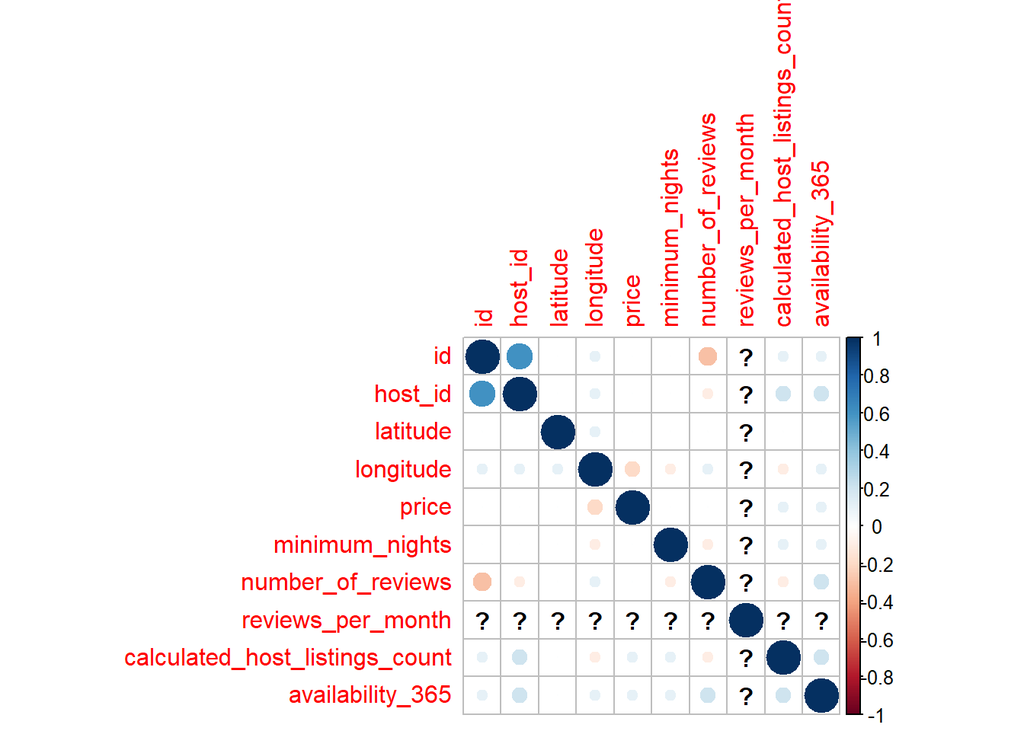

```r
corr <- round(cor(numeric_dataset), 1)
corrplot(
  corr
)
```

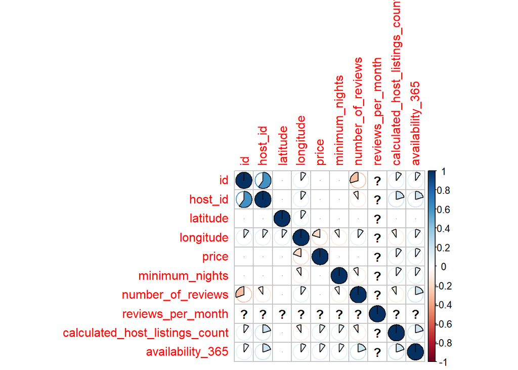

```r
corrplot(corr, method="pie")
```

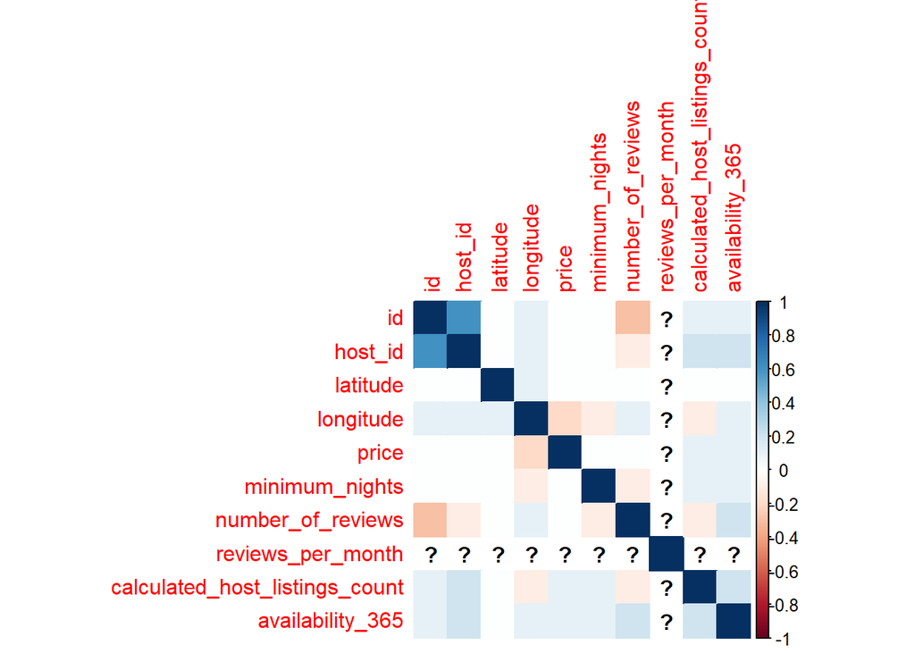

```r
corrplot(corr, method="color")
```

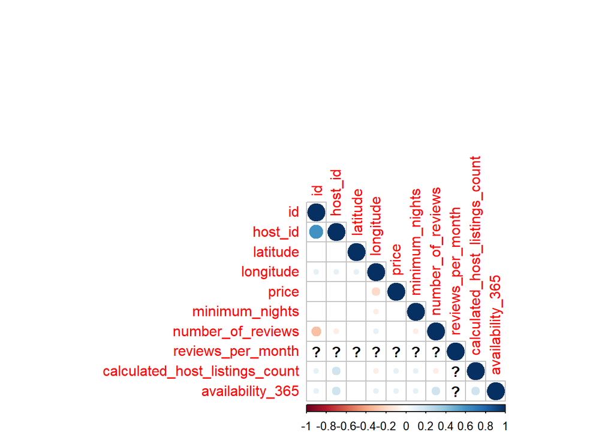

```r
corrplot(corr, type="lower")
```

Podemos hacer boxplots para ver como están distribuidos nuestros datos:

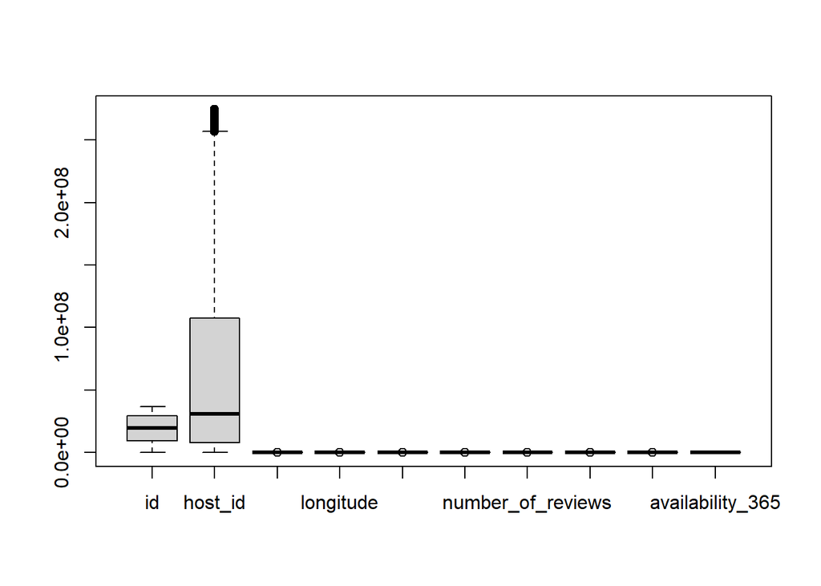

```r
boxplot(numeric_dataset)
```

Dejemos algunas columnas:

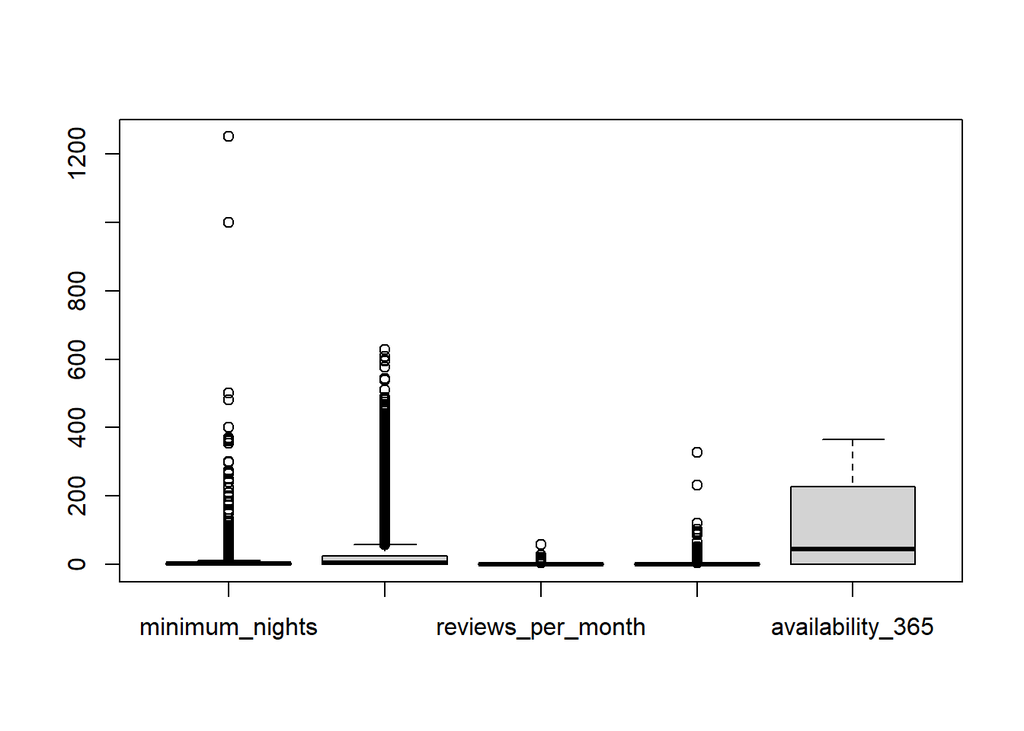

```r
boxplot(numeric_dataset[,6:10])
```

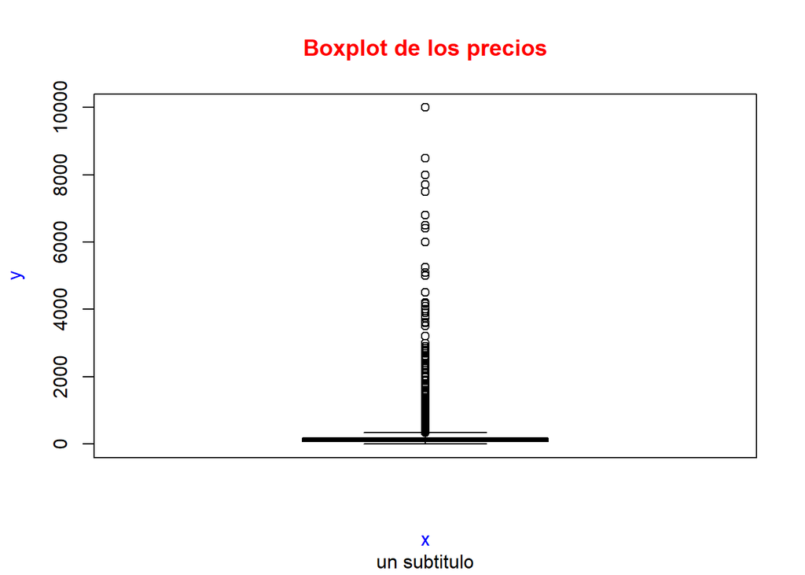

```r
boxplot(df$price,main="Boxplot de los precios",
        xlab="x",
        ylab="y",
        sub="un subtitulo",
        col.main="red", col.lab="blue", col.sub="black")
```

Parecido a los boxplots podemos hacer histogramas de las columnas que queramos:

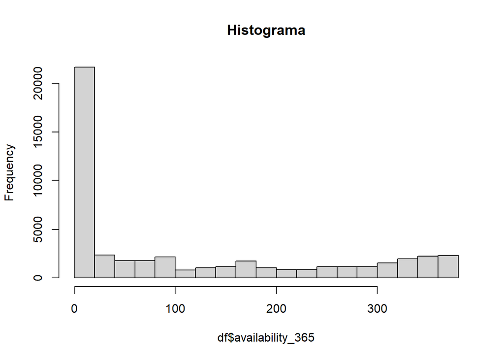

```r
hist(df$availability_365,main="Histograma")
```

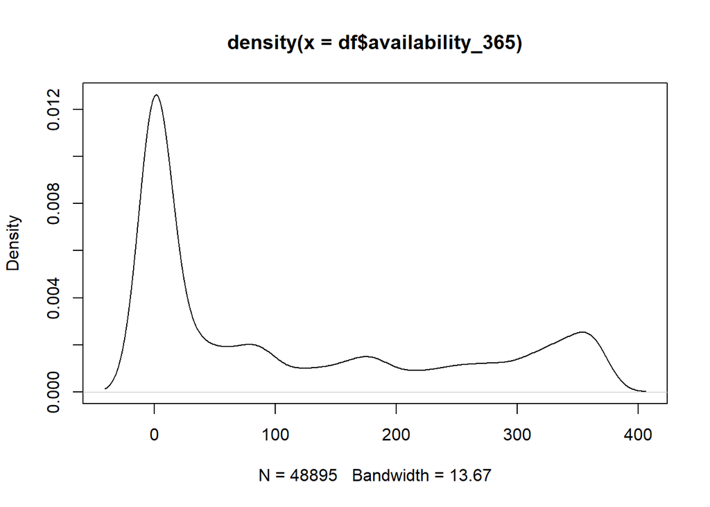

```r
plot(density(df$availability_365))
```

Ahora veamos como hacer un grafico de barras, pero usando ggplot. Esta libreria permite hacer gráficos más elaborados. La idea principal detrás de ggplot es el uso de la “Gramática de Gráficos”, que nos ayuda a generar gráficos con una sintaxis más cómoda, que separa los componentes de un gráfico en distintas “capas”.

Para esto usaremos un subconjunto de los datos

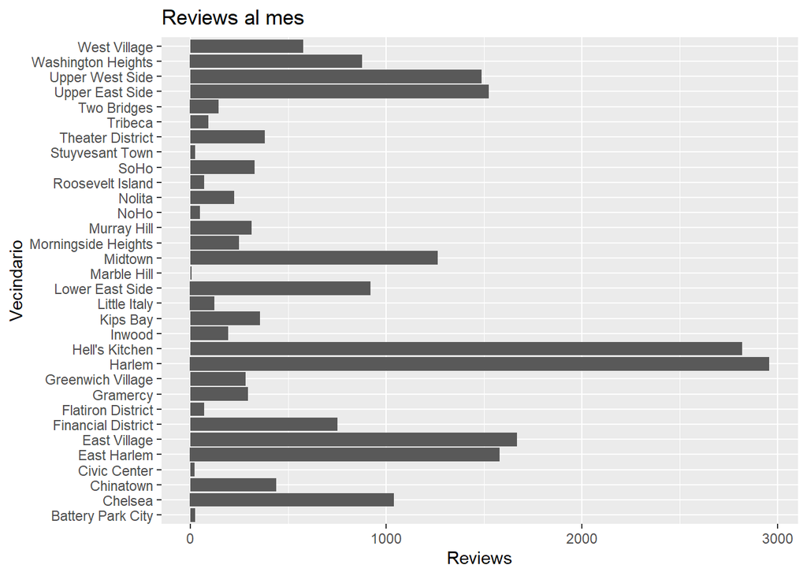

```r
manhattan = df[df$neighbourhood_group =="Manhattan",]

ggplot(manhattan) +   # asociamos un data frame a ggplot
  geom_bar(aes(x = neighbourhood, y = reviews_per_month), stat="identity") +   # creamos un gráfico de barras como una capa
  coord_flip() +  # transformamos el gráfico invirtiendo los ejes de coordenadas (sólo visualmente)
  ggtitle("Reviews al mes") + # título
  xlab("Vecindario") + ylab("Reviews")  # etiquetas
```

Tambien podemos contar la cantidad de datos de cada vecindario

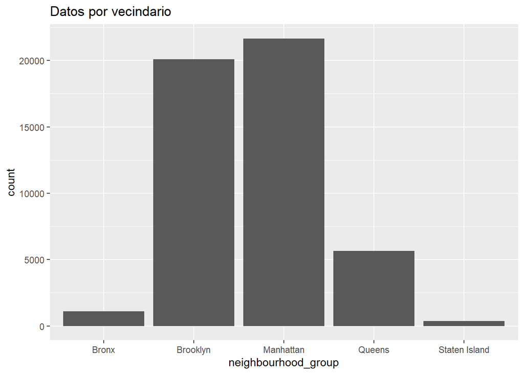

```r
ggplot(df) +
 geom_bar(aes(x=neighbourhood_group)) +
  ggtitle("Datos por vecindario")
```

Algo tambien muy util es ver relaciones entre dos variable con un scatter plot:

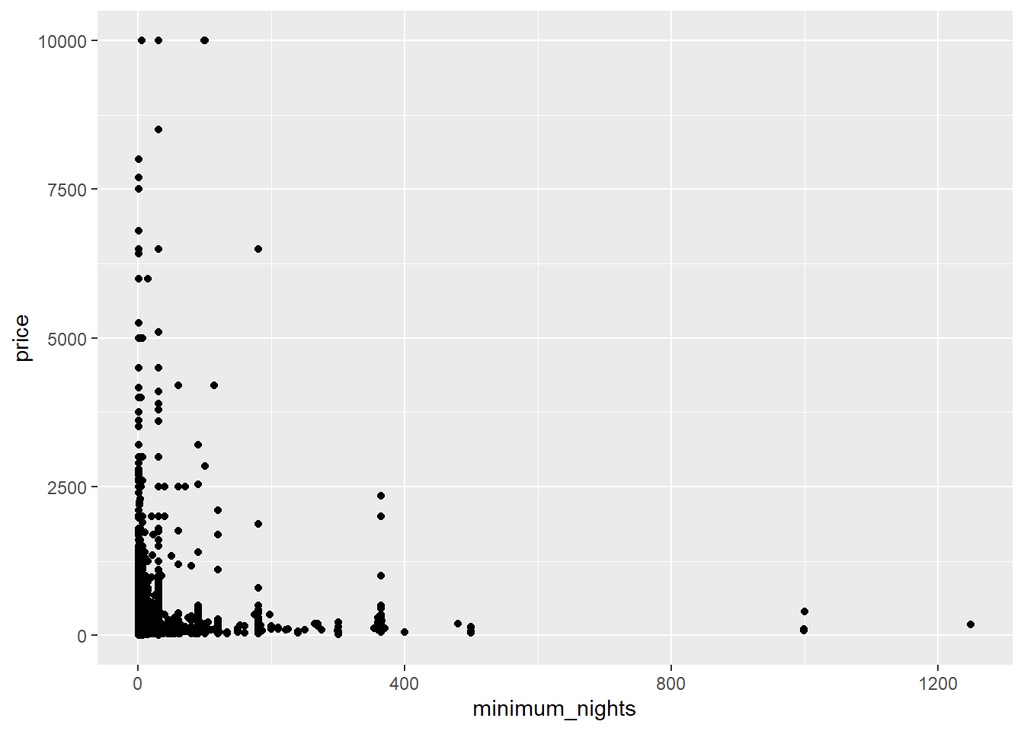

```r
ggplot(data = df) +
  geom_point(mapping = aes(x = minimum_nights, y = price))
```

Tambien lo podemos hacer sin ggplot, con solo r:

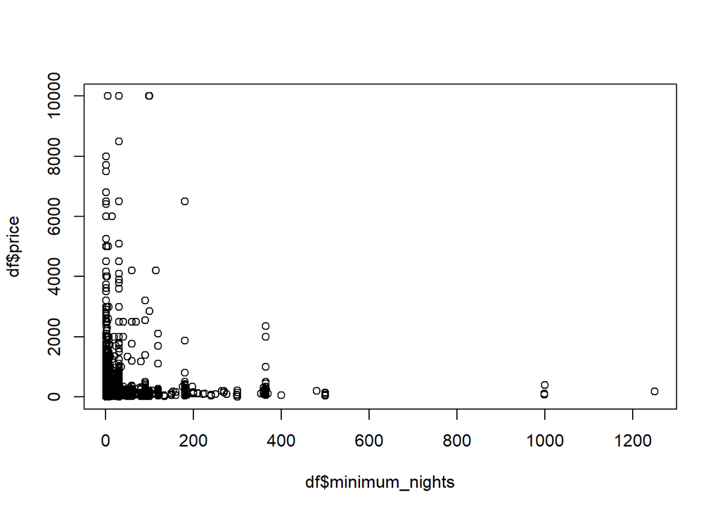

```r
plot(df$minimum_nights,df$price)
```

Otro ejempor:

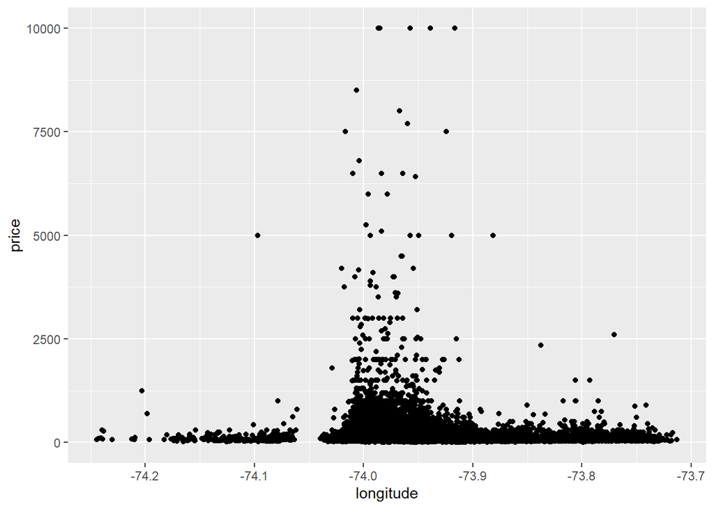

```r
ggplot(data = df) +
  geom_point(mapping = aes(x = longitude, y = price))
```

Con pairs podemos hacer una matriz con los scatterplts de las variables:

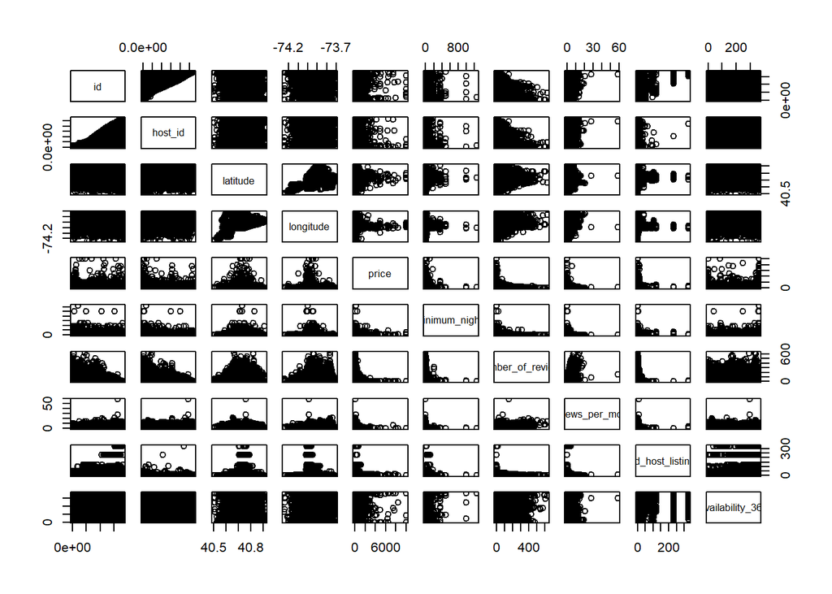

```r
pairs(numeric_dataset)
```

# Limpieza de datos

Ahora que sabemos más o menos con que estamos trabajando hay que pasar a limpiar los datos. Empecemos con con borrar los datos nulos:

```r
df = na.omit(df)
```

Saquemos outliers:

```r
# definimos nuestros limites de valores a considerar
quartiles <- quantile(df$price, probs=c(.25, .75), na.rm = FALSE)
IQR <- IQR(df$price)

Lower <- quartiles[1] - 1.5*IQR
Upper <- quartiles[2] + 1.5*IQR

df <- df[df$price > Lower & df$price < Upper,]
```

Y saquemos una columna que no nos aporta mucho:

```r
df <- df[, -which(names(df) == "host_name")]
```

Veamos con cuantos datos quedamos:

```r
dim(df)
```

```
## [1] 36766    15
```

# Operaciones con Dataframes

Algo importante tambien es manejar los dataframes.

Con aggregate podemos calcular resúmenes estadísticos para subconjuntos de datos. Esta funcion aplica una funcion a ciertas columnas.

Aqui calcularemos el precio promedio por vecindario agrupado:

```r
aggregate(price ~ neighbourhood_group, df, FUN=mean)
```

```
##   neighbourhood_group     price
## 1               Bronx  74.66474
## 2            Brooklyn 105.81232
## 3           Manhattan 141.25313
## 4              Queens  87.64197
## 5       Staten Island  87.16346
```

Tambien podemos hilar mas fino y hacerlo por vecindario agrupado y vecindario:

```r
aggregate(price ~ neighbourhood_group + neighbourhood, df, FUN=mean)
```

```
##     neighbourhood_group              neighbourhood     price
## 1                 Bronx                   Allerton  80.61111
## 2         Staten Island              Arden Heights  67.25000
## 3         Staten Island                   Arrochar  91.57895
## 4                Queens                    Arverne 133.39344
## 5                Queens                    Astoria  95.46209
## 6              Brooklyn                 Bath Beach  84.80000
## 7             Manhattan          Battery Park City 160.12121
## 8              Brooklyn                  Bay Ridge  94.89381
## 9                Queens                Bay Terrace 118.80000
## 10        Staten Island Bay Terrace, Staten Island 102.50000
## 11                Bronx                 Baychester  78.00000
## 12               Queens                    Bayside  97.40000
## 13               Queens                  Bayswater  92.27273
## 14             Brooklyn         Bedford-Stuyvesant  94.96398
```

[output cut: 204 more lines]

Cuando queremos ver los valore unicos de una columna usamos unique:

```r
unique(df$neighbourhood_group)
```

```
## [1] "Brooklyn"      "Manhattan"     "Queens"        "Staten Island"
## [5] "Bronx"
```

Y tambien podemos ordenar los datos ascendentemente:

```r
#Para hacer el ejemplo pequeño, vamos a tomar los 10 primeros datos

df_reducido <- df[1:10,]

# Ordenar ascendentemente la columna Cantidad
df_reducido[order(df_reducido$price), ]
```

```
##      id                                             name host_id
## 7  5121                                  BlissArtsSpace!    7356
## 8  5178                 Large Furnished Room Near B'way     8967
## 9  5203               Cozy Clean Guest Room - Family Apt    7490
## 5  5022 Entire Apt: Spacious Studio/Loft by central park    7192
## 4  3831                  Cozy Entire Floor of Brownstone    4869
## 11 5295                 Beautiful 1br on Upper West Side    7702
## 1  2539               Clean & quiet apt home by the park    2787
## 10 5238               Cute & Cozy Lower East Side 1 bdrm    7549
## 6  5099        Large Cozy 1 BR Apartment In Midtown East    7322
## 2  2595                            Skylit Midtown Castle    2845
##    neighbourhood_group      neighbourhood latitude longitude       room_type
## 7             Brooklyn Bedford-Stuyvesant 40.68688 -73.95596    Private room
## 8            Manhattan     Hell's Kitchen 40.76489 -73.98493    Private room
## 9            Manhattan    Upper West Side 40.80178 -73.96723    Private room
```

[output cut: 29 more lines]

y descendentemente:

```r
# Ordenar descendente
df_reducido[order(df_reducido$price, decreasing = TRUE), ]
```

```
##      id                                             name host_id
## 2  2595                            Skylit Midtown Castle    2845
## 6  5099        Large Cozy 1 BR Apartment In Midtown East    7322
## 10 5238               Cute & Cozy Lower East Side 1 bdrm    7549
## 1  2539               Clean & quiet apt home by the park    2787
## 11 5295                 Beautiful 1br on Upper West Side    7702
## 4  3831                  Cozy Entire Floor of Brownstone    4869
## 5  5022 Entire Apt: Spacious Studio/Loft by central park    7192
## 8  5178                 Large Furnished Room Near B'way     8967
## 9  5203               Cozy Clean Guest Room - Family Apt    7490
## 7  5121                                  BlissArtsSpace!    7356
##    neighbourhood_group      neighbourhood latitude longitude       room_type
## 2            Manhattan            Midtown 40.75362 -73.98377 Entire home/apt
## 6            Manhattan        Murray Hill 40.74767 -73.97500 Entire home/apt
## 10           Manhattan          Chinatown 40.71344 -73.99037 Entire home/apt
```

[output cut: 29 more lines]

Otra forma de lo mismo:

```r
df_reducido[order(-df_reducido$price), ]
```

```
##      id                                             name host_id
## 2  2595                            Skylit Midtown Castle    2845
## 6  5099        Large Cozy 1 BR Apartment In Midtown East    7322
## 10 5238               Cute & Cozy Lower East Side 1 bdrm    7549
## 1  2539               Clean & quiet apt home by the park    2787
## 11 5295                 Beautiful 1br on Upper West Side    7702
## 4  3831                  Cozy Entire Floor of Brownstone    4869
## 5  5022 Entire Apt: Spacious Studio/Loft by central park    7192
## 8  5178                 Large Furnished Room Near B'way     8967
## 9  5203               Cozy Clean Guest Room - Family Apt    7490
## 7  5121                                  BlissArtsSpace!    7356
##    neighbourhood_group      neighbourhood latitude longitude       room_type
## 2            Manhattan            Midtown 40.75362 -73.98377 Entire home/apt
## 6            Manhattan        Murray Hill 40.74767 -73.97500 Entire home/apt
## 10           Manhattan          Chinatown 40.71344 -73.99037 Entire home/apt
```

[output cut: 29 more lines]